# Annual Report Data Analysis - Question 2.01 and 2.02

Cristin Young and Tristan Burgess

2026-03-23

# 2. Did the EBP/CDEP Workstream increase access to services for targeted populations?

# Question 2.01: Did successful transition rates out of EBP/CDEP services differ by location?

THREE inclusion criteria: 1. must have initial time point data (i.e., be enrolled in an intervention), 2. must have a valid reason for discharge selected at time of discharge (i.e., excludes those with “no reason selected”), 3. client must be attached to a specific grantee location.

## % successful completion at discharge by location

| location | total | successful | perc_success |
| --- | --- | --- | --- |
| A Balanced Life, Inc. | 13 | 13 | 100.0 |
| A Greater Hope - Victorville | 2 | 0 | 0.0 |
| Achieve Residential Center | 4 | 4 | 100.0 |
| Alameda County Public Health Department | 37 | 36 | 97.3 |
| Alisal Integrated Health Center | 4 | 4 | 100.0 |
| Almond Acres Charter Academy | 2 | 0 | 0.0 |
| Alpha Behavioral Counseling Center | 4 | 4 | 100.0 |
| Amador High School | 7 | 7 | 100.0 |
| Arlington Regional Learning Center -RCOE | 1 | 1 | 100.0 |
| Arrowview Middle School | 26 | 26 | 100.0 |

[output cut: 476 more lines]

## % successful completion at discharge by region

| region | total | successful | perc_success |
| --- | --- | --- | --- |
| 1 | 983 | 899 | 91.5 |
| 10 | 592 | 564 | 95.3 |
| 11 | 1882 | 1872 | 99.5 |
| 2 | 199 | 176 | 88.4 |
| 3 | 647 | 589 | 91.0 |
| 4 | 97 | 82 | 84.5 |
| 5 | 419 | 312 | 74.5 |
| 6 | 403 | 345 | 85.6 |
| 7 | 776 | 676 | 87.1 |
| 8 | 1599 | 1457 | 91.1 |

[output cut: 2 more lines]

### Mapping by region

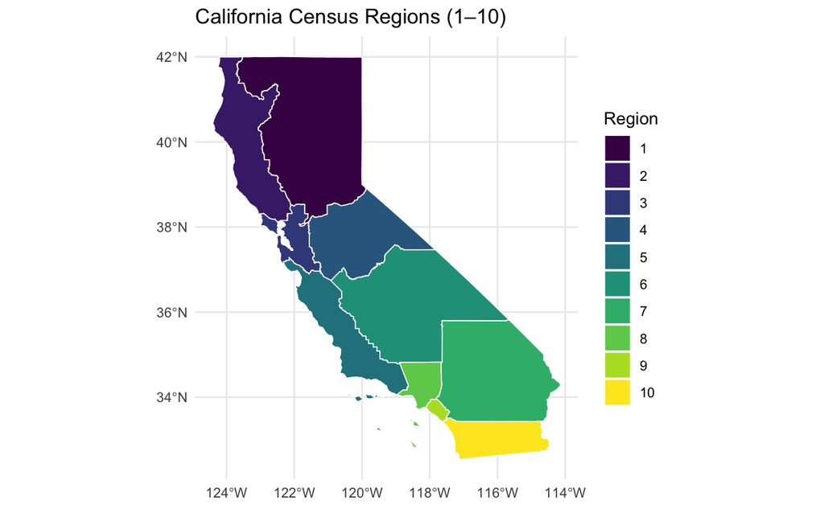

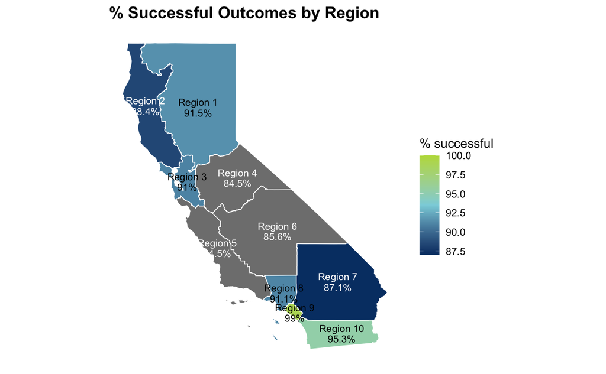

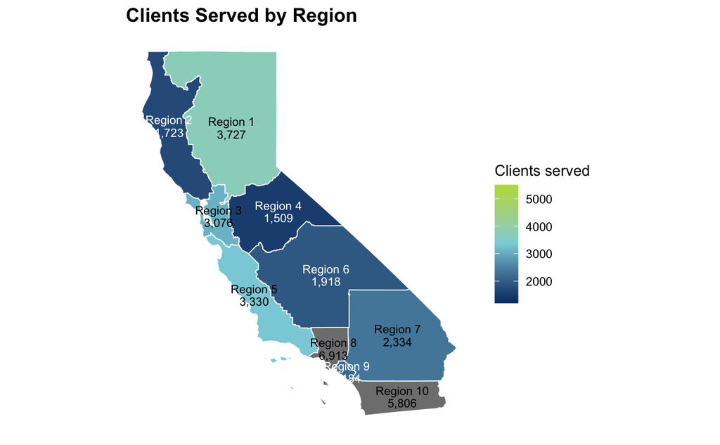

### Mapping by primary county

[output not shown]

[output not shown]

## % of those who met treatment goals (successful completion + improved score) by location

# Question 2.02: Did successful transition rates out of EBP/CDEP services differ by subpopulations?

## Race

## Race summary

Roll detailed race variables up based on first answer into: Asian, Black or African American, Don’t Know, Hispanic or Latino, Middle Eastern or North African, Native American/American Indian or Alaska Native, Native Hawaiian or Pacific Islander, Not Applicable, Prefer Not to Answer, White.

## Ethnicity

Codebook: `Chinese` = 1, `Asian Indian` = 2, `Filipino` = 3, `Vietnamese` = 4, `Korean` = 5, `Japanese` = 6, `African American` = 7, `Jamaican` = 8, `Haitian` = 9, `Nigerian` = 10, `Somali` = 11, `Mexican` = 12, `Puerto Rican` = 13, `Salvadoran` = 14, `Cuban` = 15, `Dominican` = 16, `Guatemalan` = 17, `Native Hawaiian` = 18, `Samoan` = 19, `Chamorro` = 20, `English` = 21, `German` = 22, `Irish` = 23, `Italian` = 24, `Polish` = 25, `Scottish` = 26, `2+ ethnicities selected` = 88

## Gender identity

## Sexual orientation

## Insurance status